# Autor: Luis Alberto Marín Soto

# Fecha: 29/01/2025

# **Contexto del proyecto**

El presente dataset contiene datos sobre sismos desde el año 1960 hasta el 2023. Contiene la fecha, hora, latitud, longitud, profundidad y magnitud. En este proyecto, se hará un breve análisis de datos y después se aplicarán algunos algoritmos de *machine learning* que estarán acompañados de unas métricas de evaluación y una de validación. El presente proyecto se desarrolló usando *Google Colab*.

# **Importación de las principales librerías**

```python
import pandas as pd
import matplotlib.pyplot as plt
import seaborn as sns
import numpy as np
```

```python
# ——Importación del dataset——
data = pd.read_excel("https://www.datosabiertos.gob.pe/sites/default/files/Catalogo1960_2023.xlsx")
```

# **Breve observación a los datos**

```python
data.info() # Información inicial sobre el dataset
```

[output not shown]

```python
data.isnull().sum()
```

|  | 0 |
| --- | --- |
| ID | 0 |
| FECHA_UTC | 0 |
| HORA_UTC | 0 |
| LATITUD | 0 |
| LONGITUD | 0 |
| PROFUNDIDAD | 0 |
| MAGNITUD | 0 |
| FECHA_CORTE | 0 |

**dtype:** int64

```python
data.head() # Observemos las primeras filas del dataset
```

|  | ID | FECHA_UTC | HORA_UTC | LATITUD | LONGITUD | PROFUNDIDAD | MAGNITUD | FECHA_CORTE |
| --- | --- | --- | --- | --- | --- | --- | --- | --- |
| 0 | 0 | 19600113 | 154034 | -16.145 | -72.144 | 60 | 7.5 | 20223006 |
| 1 | 1 | 19600115 | 93024 | -15.000 | -75.000 | 70 | 7.0 | 20223006 |
| 2 | 2 | 19600117 | 25758 | -14.500 | -74.500 | 150 | 6.4 | 20223006 |
| 3 | 3 | 19600123 | 33732 | -12.500 | -68.500 | 300 | 5.8 | 20223006 |
| 4 | 4 | 19600130 | 50724 | -5.500 | -77.500 | 100 | 5.7 | 20223006 |

```python
data.describe() # Medidas estadísticas
```

|  | ID | FECHA_UTC | HORA_UTC | LATITUD | LONGITUD | PROFUNDIDAD | MAGNITUD | FECHA_CORTE |
| --- | --- | --- | --- | --- | --- | --- | --- | --- |
| count | 23680.000000 | 2.368000e+04 | 23680.000000 | 23680.000000 | 23680.000000 | 23680.000000 | 23680.000000 | 2.368000e+04 |
| mean | 11839.500000 | 2.003157e+07 | 111812.436486 | -11.370460 | -75.703128 | 71.097593 | 4.722078 | 2.022353e+07 |
| std | 6835.971523 | 1.488910e+05 | 68720.122559 | 4.482472 | 3.095954 | 66.236335 | 0.438076 | 2.676719e+03 |
| min | 0.000000 | 1.960011e+07 | 6.000000 | -23.397100 | -82.893700 | 0.000000 | 3.000000 | 2.022301e+07 |
| 25% | 5919.750000 | 1.995021e+07 | 53130.750000 | -15.380000 | -77.767200 | 29.000000 | 4.500000 | 2.022301e+07 |
| 50% | 11839.500000 | 2.006081e+07 | 104544.500000 | -11.710000 | -75.744300 | 48.000000 | 4.700000 | 2.022301e+07 |
| 75% | 17759.250000 | 2.015051e+07 | 171904.000000 | -7.909500 | -73.600000 | 106.000000 | 4.900000 | 2.022301e+07 |
| max | 23679.000000 | 2.023123e+07 | 235956.000000 | -1.490000 | -66.980700 | 743.000000 | 8.400000 | 2.024010e+07 |

# **Manipulación de datos**

Hay variables como ID, FECHA_UTC, HORA_UTC, FECHA_CORTE que están incluidos en la obtención de las medidas de tendencia central (tienen como dtype: int64), asi que convirtámoslas en lo que deberían ser.

La nueva variable que almacenará todos los cambios se llamará "data_cambiada".

```python
# ——Eliminamos la columna FECHA_CORTE porque no nos será de utilidad——
data_cambiada = data.drop(columns = ['FECHA_CORTE'])
```

```python
# ——Hacemos que ID sea nuestro índice——
data_cambiada = data_cambiada.set_index('ID')
```

```python
# ——Transformación de las columnas FECHA_UTC y HORA_UTC——
# ======En el caso de FECHA_UTC======
data_cambiada['FECHA_UTC'] = pd.to_datetime(data_cambiada['FECHA_UTC'].astype(str), format = '%Y%m%d')                                             # Establecemos el formato de la fecha
# ======En el caso de HORA_UTC======
data_cambiada['HORA_UTC'] = data_cambiada['HORA_UTC'].astype(str).str.zfill(6)                                                                     # Aseguramos que tenga 6 dígitos
data_cambiada['HORA_UTC'] = data_cambiada['HORA_UTC'].str[:2] + ':' + data_cambiada['HORA_UTC'].str[2:4] + ':' + data_cambiada['HORA_UTC'].str[4:] # Manipulamos un poco el formato presente
data_cambiada['HORA_UTC'] = pd.to_datetime(data_cambiada['HORA_UTC'], format='%H:%M:%S').dt.time                                                   # Convertir en formato de horas, minutos y segundos
```

```python
# ——Creación de la columna HORA_HECHO que almacenará la hora exacta del sismo——
data_cambiada['HORA_HECHO'] = data_cambiada['HORA_UTC'].astype(str).str[:2].astype(int)
```

```python
# ——Reordenar desde la fecha más antigua hasta la más reciente——
data_cambiada = data_cambiada.sort_values(by='FECHA_UTC', ascending=True).reset_index(drop=True)
```

```python
# ———Calculamos el número de días transcurridos entre cada sismo———
data_cambiada['DIAS_TRANSCURRIDOS'] = data_cambiada['FECHA_UTC'].diff().dt.days
data_cambiada.iloc[0,7] = 16 # Como se usa diff(), esta celda estará vacía, así que tomaremos el inicio del año para calcular los dias transcurridos
data_cambiada['DIAS_TRANSCURRIDOS'] = data_cambiada['DIAS_TRANSCURRIDOS'].astype(int)
```

```python
# ———Clasificamos los años según décadas. Por ejemplo: Años 1990———
data_cambiada['DECADA'] = (data_cambiada['FECHA_UTC'].dt.year // 10) * 10
data_cambiada['DECADA'] = 'Años ' + data_cambiada['DECADA'].astype(str)
# ———Clasificamos las horas como momentos del día: Mañana, Tarde, Noche y Madrugada———
def clasificar_hora(hora):
    hora_int = int(hora)
    if 5 <= hora_int < 12:
        return 'Mañana'
    elif 12 <= hora_int < 18:
        return 'Tarde'
    elif 18 <= hora_int < 24:
        return 'Noche'
    else:
        return 'Madrugada'

data_cambiada['MOMENTO_DIA'] = data_cambiada['HORA_UTC'].astype(str).str[:2].apply(clasificar_hora) # Aplicar la función a la columna 'HORA_UTC'
```

```python
data_cambiada.info() # Información del dataset manipulado
```

```
<class 'pandas.core.frame.DataFrame'>
RangeIndex: 23680 entries, 0 to 23679
Data columns (total 10 columns):
 #   Column              Non-Null Count  Dtype
---  ------              --------------  -----
 0   FECHA_UTC           23680 non-null  datetime64[ns]
 1   HORA_UTC            23680 non-null  object
 2   LATITUD             23680 non-null  float64
 3   LONGITUD            23680 non-null  float64
 4   PROFUNDIDAD         23680 non-null  int64
 5   MAGNITUD            23680 non-null  float64
 6   HORA_HECHO          23680 non-null  int64
 7   DIAS_TRANSCURRIDOS  23680 non-null  int64
 8   DECADA              23680 non-null  object
 9   MOMENTO_DIA         23680 non-null  object
dtypes: datetime64[ns](1), float64(3), int64(3), object(3)
memory usage: 1.8+ MB
```

```python
data_cambiada.head() # Primeras filas del dataset manipulado
```

|  | FECHA_UTC | HORA_UTC | LATITUD | LONGITUD | PROFUNDIDAD | MAGNITUD | HORA_HECHO | DIAS_TRANSCURRIDOS | DECADA | MOMENTO_DIA |
| --- | --- | --- | --- | --- | --- | --- | --- | --- | --- | --- |
| 0 | 1960-01-13 | 15:40:34 | -16.145 | -72.144 | 60 | 7.5 | 15 | 16 | Años 1960 | Tarde |
| 1 | 1960-01-15 | 09:30:24 | -15.000 | -75.000 | 70 | 7.0 | 9 | 2 | Años 1960 | Mañana |
| 2 | 1960-01-17 | 02:57:58 | -14.500 | -74.500 | 150 | 6.4 | 2 | 2 | Años 1960 | Madrugada |
| 3 | 1960-01-23 | 03:37:32 | -12.500 | -68.500 | 300 | 5.8 | 3 | 6 | Años 1960 | Madrugada |
| 4 | 1960-01-30 | 05:07:24 | -5.500 | -77.500 | 100 | 5.7 | 5 | 7 | Años 1960 | Mañana |

```python
data_cambiada.sample(10) # Muestra aleatoria del dataset manipulado
```

|  | FECHA_UTC | HORA_UTC | LATITUD | LONGITUD | PROFUNDIDAD | MAGNITUD | HORA_HECHO | DIAS_TRANSCURRIDOS | DECADA | MOMENTO_DIA |
| --- | --- | --- | --- | --- | --- | --- | --- | --- | --- | --- |
| 16077 | 2013-09-30 | 15:08:26 | -15.0638 | -72.6135 | 126 | 5.0 | 15 | 0 | Años 2010 | Tarde |
| 5472 | 1993-12-31 | 09:36:53 | -15.9800 | -73.2400 | 66 | 5.0 | 9 | 1 | Años 1990 | Mañana |
| 17328 | 2014-11-28 | 04:06:15 | -3.8774 | -77.2341 | 107 | 5.3 | 4 | 0 | Años 2010 | Madrugada |
| 1654 | 1974-10-08 | 05:25:42 | -12.4950 | -76.7340 | 53 | 4.7 | 5 | 0 | Años 1970 | Mañana |
| 2667 | 1984-12-24 | 13:36:45 | -9.5140 | -71.3380 | 545 | 5.9 | 13 | 10 | Años 1980 | Tarde |
| 9616 | 2001-07-10 | 04:43:06 | -17.8926 | -71.8616 | 39 | 4.8 | 4 | 0 | Años 2000 | Madrugada |
| 925 | 1969-07-04 | 07:21:50 | -4.2260 | -80.9890 | 28 | 5.0 | 7 | 0 | Años 1960 | Mañana |
| 883 | 1969-03-01 | 23:55:13 | -17.4100 | -69.8800 | 151 | 4.8 | 23 | 2 | Años 1960 | Noche |
| 11010 | 2005-01-26 | 21:01:12 | -16.4718 | -69.7979 | 178 | 4.9 | 21 | 1 | Años 2000 | Noche |
| 12374 | 2007-08-30 | 09:20:36 | -14.1452 | -77.0289 | 33 | 4.6 | 9 | 1 | Años 2000 | Mañana |

```python
data_cambiada.describe() # Nuevos resultados en las medidas estadísticas
```

|  | FECHA_UTC | LATITUD | LONGITUD | PROFUNDIDAD | MAGNITUD | HORA_HECHO | DIAS_TRANSCURRIDOS |
| --- | --- | --- | --- | --- | --- | --- | --- |
| count | 23680 | 23680.000000 | 23680.000000 | 23680.000000 | 23680.000000 | 23680.000000 | 23680.000000 |
| mean | 2003-08-07 01:08:17.432432512 | -11.370460 | -75.703128 | 71.097593 | 4.722078 | 10.883488 | 0.987289 |
| min | 1960-01-13 00:00:00 | -23.397100 | -82.893700 | 0.000000 | 3.000000 | 0.000000 | 0.000000 |
| 25% | 1995-02-13 18:00:00 | -15.380000 | -77.767200 | 29.000000 | 4.500000 | 5.000000 | 0.000000 |
| 50% | 2006-08-09 00:00:00 | -11.710000 | -75.744300 | 48.000000 | 4.700000 | 10.000000 | 0.000000 |
| 75% | 2015-05-10 00:00:00 | -7.909500 | -73.600000 | 106.000000 | 4.900000 | 17.000000 | 1.000000 |
| max | 2023-12-31 00:00:00 | -1.490000 | -66.980700 | 743.000000 | 8.400000 | 23.000000 | 88.000000 |
| std | NaN | 4.482472 | 3.095954 | 66.236335 | 0.438076 | 6.868666 | 2.063165 |

# **Análisis de datos**

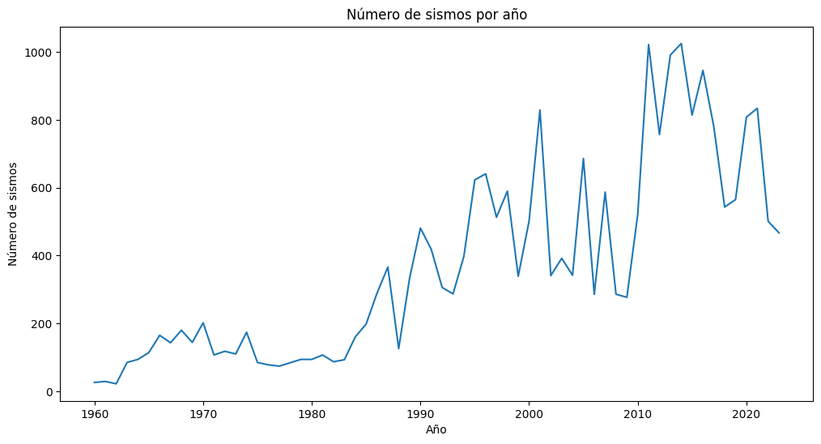

```python
# ———Conteo de sismos por año———
earthquakes_per_year = data_cambiada.groupby(data_cambiada['FECHA_UTC'].dt.year).size()

plt.figure(figsize=(12, 6))
sns.lineplot(x=earthquakes_per_year.index, y=earthquakes_per_year.values)
plt.xlabel('Año')
plt.ylabel('Número de sismos')
plt.title('Número de sismos por año')
plt.show()
```

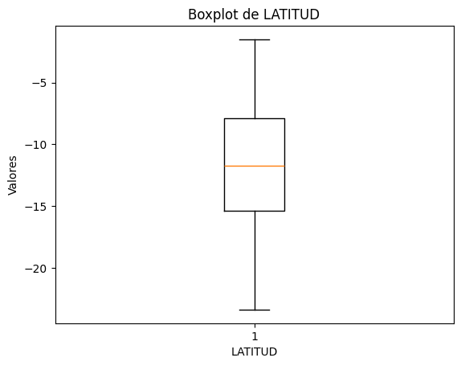

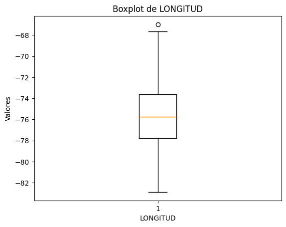

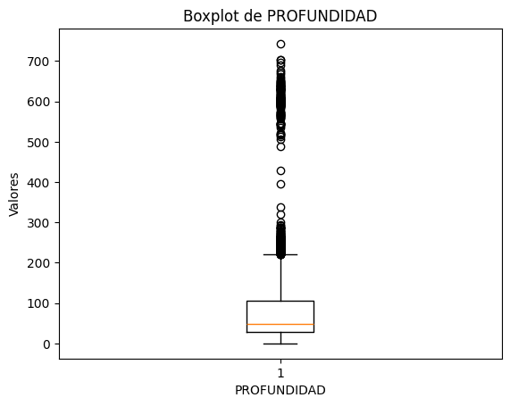

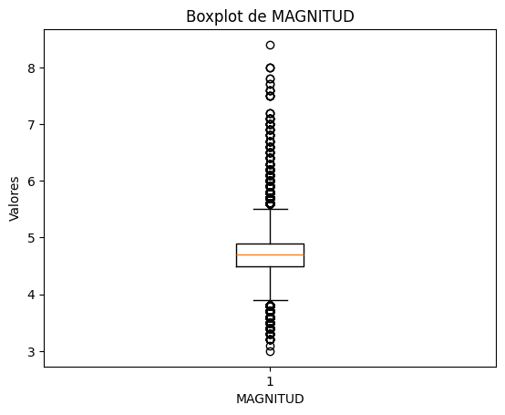

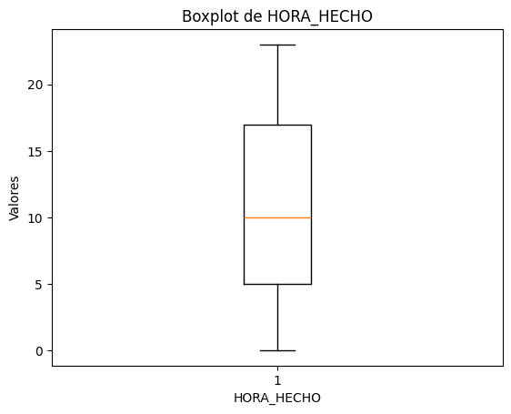

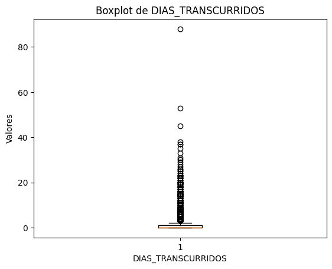

```python
# ———Generación de un boxplot para cada variable numérica———
for columna in data_cambiada.columns:
    try:
        data = data_cambiada[columna]

        if data.dtype.kind not in 'if' or len(data) == 0:
            continue  # Si no es int (i) o float (f), o está vacía, salta la columna

        plt.boxplot(data)
        plt.title(f'Boxplot de {columna}')
        plt.xlabel(columna)
        plt.ylabel('Valores')
        plt.show()
    except TypeError:
      pass
```

```python
pd.crosstab(data_cambiada['DECADA'], data_cambiada['MOMENTO_DIA']) # Tabla cruzada entre 'DECADA' y 'MOMENTO_DIA'
```

| MOMENTO_DIA DECADA | Madrugada | Mañana | Noche | Tarde |
| --- | --- | --- | --- | --- |
| Años 1960 | 225 | 322 | 207 | 248 |
| Años 1970 | 236 | 360 | 243 | 287 |
| Años 1980 | 395 | 606 | 421 | 431 |
| Años 1990 | 977 | 1434 | 1053 | 1132 |
| Años 2000 | 984 | 1474 | 1054 | 1016 |
| Años 2010 | 1912 | 2656 | 1708 | 1689 |
| Años 2020 | 587 | 869 | 570 | 584 |

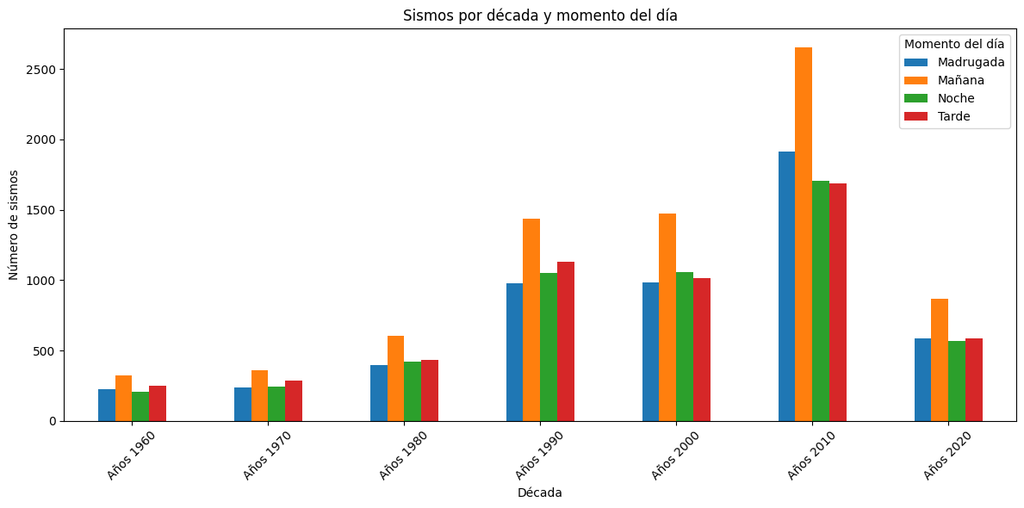

```python
# ———Creación de un gráfico que muestre los datos de la tabla cruzada———
tabla_cruzada_1 = pd.crosstab(data_cambiada['DECADA'], data_cambiada['MOMENTO_DIA']) # Almacenamos la información de la tabla cruzada en una variable llamada "tabla_cruzada_1"

tabla_cruzada_1.plot(kind='bar', figsize=(12, 6)) # Generación del gráfico y sus detalles
plt.title('Sismos por década y momento del día')
plt.xlabel('Década')
plt.ylabel('Número de sismos')
plt.xticks(rotation=45)
plt.legend(title='Momento del día')
plt.tight_layout()
plt.show()
```

```python
# ———Se van a agrupar las columnas 'DECADA' y 'MOMENTO_DIA' para usar las funciones de agregación: máximo y mínimo———
Grupo1 = data_cambiada.groupby(['DECADA','MOMENTO_DIA'])['MAGNITUD'].agg(['max','min']) # Se almacenará en la variable "Grupo1"
Grupo1
```

| DECADA | MOMENTO_DIA | max | min |
| --- | --- | --- | --- |
| Años 1960 | Madrugada | 7.5 | 4.5 |
|  | Mañana | 7.0 | 4.5 |
|  | Noche | 8.0 | 4.5 |
|  | Tarde | 7.8 | 4.5 |
| Años 1970 | Madrugada | 7.1 | 4.5 |
|  | Mañana | 6.9 | 4.0 |
|  | Noche | 7.8 | 4.0 |
|  | Tarde | 7.7 | 4.2 |
| Años 1980 | Madrugada | 6.6 | 4.1 |
|  | Mañana | 6.4 | 4.2 |
|  | Noche | 7.0 | 4.1 |
|  | Tarde | 6.7 | 4.2 |
| Años 1990 | Madrugada | 7.0 | 4.0 |
|  | Mañana | 7.2 | 4.0 |
|  | Noche | 6.8 | 4.0 |
|  | Tarde | 7.7 | 4.0 |
| Años 2000 | Madrugada | 7.5 | 4.0 |
|  | Mañana | 7.6 | 4.0 |
|  | Noche | 8.4 | 4.0 |
|  | Tarde | 6.6 | 4.0 |
| Años 2010 | Madrugada | 6.6 | 4.0 |
|  | Mañana | 8.0 | 4.0 |
|  | Noche | 7.6 | 4.0 |
|  | Tarde | 7.1 | 4.0 |
| Años 2020 | Madrugada | 6.3 | 3.2 |
|  | Mañana | 7.5 | 3.1 |
|  | Noche | 6.8 | 3.2 |
|  | Tarde | 7.2 | 3.0 |

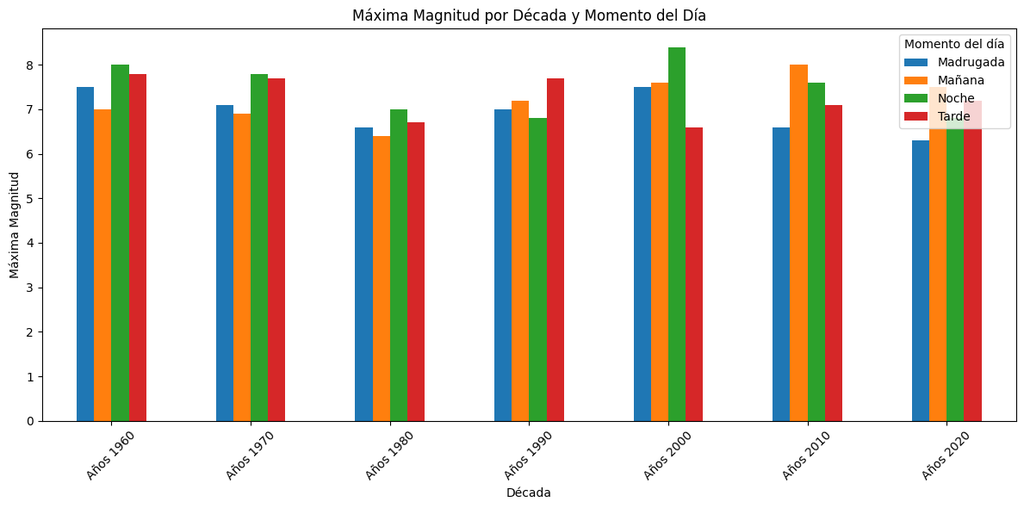

```python
Grupo1['max'].unstack().plot(kind='bar', figsize=(12, 6))
plt.title('Máxima Magnitud por Década y Momento del Día')
plt.xlabel('Década')
plt.ylabel('Máxima Magnitud')
plt.xticks(rotation=45)
plt.legend(title='Momento del día')
plt.tight_layout()
plt.show()
```

```python
# ———Se va a agrupar la columna 'HORA_HECHO' según 'MAGNITUD' para hacer un conteo y saber exactamente cuantos sismos se dieron en ciertas horas del día
# ———Así como ver la máxima y mínima magnitud———
Grupo2 = data_cambiada.groupby('HORA_HECHO')['MAGNITUD'].agg(['count','max','min']) # Se almacenará en la variable "Grupo2"
Grupo2
```

| HORA_HECHO | count | max | min |
| --- | --- | --- | --- |
| 0 | 1010 | 6.4 | 3.2 |
| 1 | 1041 | 7.5 | 3.3 |
| 2 | 1093 | 6.9 | 3.2 |
| 3 | 1035 | 6.3 | 3.2 |
| 4 | 1137 | 7.1 | 3.3 |
| 5 | 1158 | 7.0 | 3.3 |
| 6 | 1206 | 7.2 | 3.3 |
| 7 | 1116 | 8.0 | 3.4 |
| 8 | 1171 | 7.0 | 3.4 |
| 9 | 1067 | 7.6 | 3.3 |
| 10 | 1038 | 7.5 | 3.2 |
| 11 | 965 | 6.4 | 3.1 |
| 12 | 880 | 7.5 | 3.4 |
| 13 | 920 | 6.6 | 3.0 |
| 14 | 952 | 7.7 | 3.4 |
| 15 | 848 | 7.5 | 3.3 |
| 16 | 845 | 7.7 | 3.2 |
| 17 | 942 | 7.8 | 3.2 |
| 18 | 867 | 6.9 | 3.3 |
| 19 | 843 | 7.0 | 3.2 |
| 20 | 874 | 8.4 | 3.2 |
| 21 | 875 | 8.0 | 3.4 |
| 22 | 874 | 7.6 | 3.3 |
| 23 | 923 | 8.0 | 3.3 |

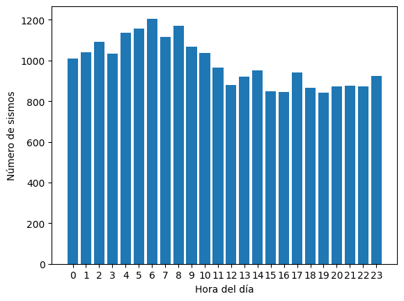

```python
plt.bar(Grupo2.index, Grupo2['count'])
plt.xlabel('Hora del día')
plt.ylabel('Número de sismos')
plt.xticks(Grupo2.index)
plt.show()
```

```python
pd.crosstab(data_cambiada['HORA_HECHO'], data_cambiada['DECADA'])
```

| DECADA HORA_HECHO | Años 1960 | Años 1970 | Años 1980 | Años 1990 | Años 2000 | Años 2010 | Años 2020 |
| --- | --- | --- | --- | --- | --- | --- | --- |
| 0 | 50 | 46 | 87 | 179 | 200 | 348 | 100 |
| 1 | 43 | 42 | 80 | 232 | 193 | 345 | 106 |
| 2 | 42 | 51 | 73 | 199 | 189 | 421 | 118 |
| 3 | 34 | 49 | 68 | 180 | 199 | 375 | 130 |
| 4 | 56 | 48 | 87 | 187 | 203 | 423 | 133 |
| 5 | 49 | 56 | 93 | 199 | 230 | 405 | 126 |
| 6 | 42 | 66 | 90 | 245 | 238 | 406 | 119 |
| 7 | 44 | 45 | 74 | 181 | 224 | 418 | 130 |
| 8 | 46 | 46 | 104 | 222 | 229 | 406 | 118 |
| 9 | 56 | 51 | 74 | 209 | 179 | 362 | 136 |
| 10 | 43 | 56 | 88 | 187 | 201 | 337 | 126 |
| 11 | 42 | 40 | 83 | 191 | 173 | 322 | 114 |
| 12 | 51 | 44 | 70 | 177 | 179 | 287 | 72 |
| 13 | 38 | 42 | 73 | 196 | 184 | 285 | 102 |
| 14 | 53 | 50 | 81 | 189 | 163 | 298 | 118 |
| 15 | 34 | 42 | 73 | 184 | 162 | 262 | 91 |
| 16 | 38 | 53 | 60 | 192 | 156 | 257 | 89 |
| 17 | 34 | 56 | 74 | 194 | 172 | 300 | 112 |
| 18 | 42 | 43 | 71 | 194 | 162 | 270 | 85 |
| 19 | 32 | 27 | 75 | 161 | 182 | 267 | 99 |
| 20 | 27 | 43 | 58 | 190 | 160 | 294 | 102 |
| 21 | 37 | 42 | 70 | 154 | 192 | 276 | 104 |
| 22 | 34 | 48 | 74 | 168 | 171 | 284 | 95 |
| 23 | 35 | 40 | 73 | 186 | 187 | 317 | 85 |